# 10 Numeric integration with Julia

A notebook for this material: ipynb

## 10.1 Introduction

Let $f(x)$ be some non-negative, continuous function over the interval $[a,b]$. The area under the graph of $f(x)$ is given by the definite integral:

$$\text{Area under f} = \int_a^b f(x) dx$$

Computing this area is *often* made easier with the Fundamental Theorem of Calculus which states in one form that one can compute a definite integral through knowledge of an antiderivative. In particular, if $F(x)$ is an antiderivative for $f(x)$, a continuous function, then

$$\int_a^b f(x) dx = F(b) - F(a).$$

This is great as long as some antiderivative is known. There are several different techniques for finding antiderivatives. The `integrate` function in the `SymPy` package can do many of them:

```julia
using MTH229
using Plots
plotly()
```

```julia
f(x) = x^3 - cos(x) + x*log(x)
@syms x
integrate(f(x), x)
```

\[ \frac{x^{4}}{4} + \frac{x^{2} \log{\left(x \right)}}{2} - \frac{x^{2}}{4} - \sin{\left(x \right)} \]

To find the definite integral, say from $1$ to $10$ we have:

```julia
integrate(f(x), (x, 1, 10))
```

\[ - \sin{\left(10 \right)} + \sin{\left(1 \right)} + 50 \log{\left(10 \right)} + 2475 \]

If all functions had antiderivatives that could be found symbolically, there wouldn’t be much more to say. However, it is a fact of life that not all nice functions will have an antiderivative in a convenient form. A test for such functions is provided in [Risch’s algorithm](http://en.wikipedia.org/wiki/Risch_algorithm). In cases where no workable antiderivative is available, the above approach is of no help. Rather, to find the area one can turn to numeric approximations that progressively get better as more approximations are taken.

One such approximation is given by the familiar Riemann sums, which we will look at here. However, the problem of trying to find the area of geometric figures did not start with Riemann some 150 years ago, indeed it has a much longer history. In the time of Pythagorus the idea of calculating area was one of being able to construct a square of equal area to a figure. This was known as *quadrature*. Finding such answers for figures bounded by curves was difficult, though [Archimedes](http://en.wikipedia.org/wiki/The_Quadrature_of_the_Parabola) effectively computed the area under $f(x) = x^2$ about 2,000 years before Riemann sums using triangles, not rectangles to approximate the area. By medieval Europe, the term *quadrature* evolved to be the computation of an area by any means. For example, Galileo and Roberval found the area bounded by a cycloid arch. Along the way, other approximations were used. We will see those due to Simpson and Gauss, both predating Riemann.

## 10.2 Riemann sums

In 1854 Riemann was the first to give a rigorous definition of the integral of a continuous function on a closed interval, the problem we wish to solve here, using the concept of a *Riemann sum*. A Riemann sum is one of the simplest to understand approximations to the area under a curve. The basic idea is that the interval $[a,b]$ is partitioned through points $a = x_0 < x_1 < \cdots x_n = b$ and the area under $f(x)$ between $x_i$ and $x_{i+1}$ is approximated by a rectangle with the base $x_{i+1} - x_i$ and height given by $f(x_i^*)$, where $x_i^*$ is some point in the interval $[x_i, x_{i+1}]$. Typical choices are the left point or the right point of the interval, or the $x$ value which minimizes or maximizes $f$ over the interval. The figure shows these four choices for some sample function. For a *Riemann integrable* function, such as a continuous function on $[a,b]$, any of the choices will yield the same value as the partition’s mesh shrinks to $0$.

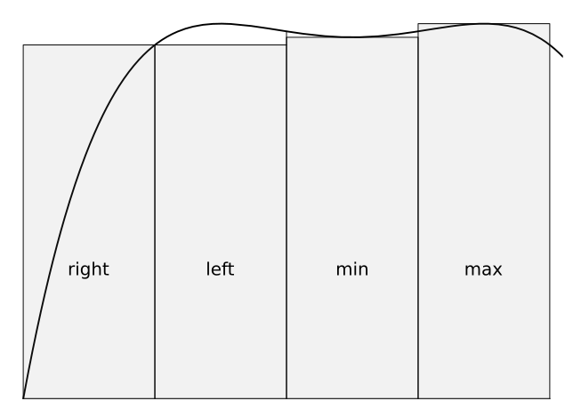

As with other limits, we can numerically approximate the limit by computing the Riemann sum for some partition. The steps for this include:

- creating a partition of $[a,b]$. We will use evenly spaced points for convenience.
- Selecting the $x_i^*$ within the partition
- Computing the values $f(x_i^*)(x_{i+1} - x_i)$ for each $i$
- adding these values up

If we partition $[a,b]$ into $n$ same sized intervals, then each has length $\delta = (b-a)/n$ and so the points are separated by this amount. As such, we can choose our $a = x_0 < x_1 < \dots < x_n = b$ with commands like:

```julia
a, b, n = 1, 3, 5;
delta = (b-a)/n;
xs = a .+ (0:n) * delta
```

```
1.0:0.4:3.0
```

To apply a function to a range of values, we may use a map, a comprehension, a `for` loop or the “dot” notation. We will use broadcasting here. Recall, the syntax:

```julia
f(x) = x^2
fxs = f.(xs)
```

```
6-element Vector{Float64}:
 1.0
 1.9599999999999997
 3.24
 4.840000000000001
 6.760000000000001
 9.0
```

Now to add the numbers up. For this task, the `sum` function is available

```julia
sum(fxs)
```

```
26.8
```

Okay, just one subtlety, we really only want the points

```julia
[ a .+ (0:n-1) * delta ]
```

```
1-element Vector{StepRangeLen{Float64, Base.TwicePrecision{Float64}, Base.TwicePrecision{Float64}, Int64}}:
 1.0:0.4:2.6
```

for the left Riemann sum and the points

```julia
[ a .+ (1:n) * delta ]
```

```
1-element Vector{StepRangeLen{Float64, Base.TwicePrecision{Float64}, Base.TwicePrecision{Float64}, Int64}}:
 1.4:0.4:3.0
```

for the right.

Putting this together, here are commands to approximate the area under the curve $f(x)=x^2$ using 10 left Riemann sums:

```julia
f(x) = x^2
a, b, n = 1, 3, 10;        ## note n=10
delta = (b - a)/n;         ## nothing to change below here
xs = a .+ (0:n-1) * delta;          ## n, right is 1:n * delta
fxs = f.(xs);
sum(fxs) * delta
```

```
7.88
```

We compare this value to the known value from the Fundamental Theorem of Calculus, as $F(x) = x^3/3$ is an antiderivative:

```julia
F(x) = x^3/3
F(b) - F(a)
```

```
8.666666666666666
```

Boy, not too close. We need a better approximation of course. This can be achieved by using larger values for `n`.

### 10.2.1 Practice

#### Question

Repeat with n=100

For the same problem, let $n=100$. What do you get?

#### Question

Repeat with n=1,000

For the same problem, let $n=1000$. What do you get?

#### Question

Repeat with n=10,000

For the same problem, let $n=10,000$. is the difference between the answer and the actual answer within $0.001$?

true

false

#### Question

How big should n be? (Strang)

Let $f(x) = (10 + \cos(2\pi x))^{-1}$. For the integral over $[0,1]$, the known answer is $1/\sqrt{99}$. How big must $n$ be so that the error in the Riemann sum is less than $10^{-8}$?

10000

100

1000

10

5